# West Midlands

For each Provider which appears in the 2017/18 Initial Teacher Training (ITT) Census and which has more than 50 graduates appearing in the School Workforce Census (SWC) a map of Normal Ellipse Curves and a Cumulative Density Curve are included to detail how far the trainees travel to their first job. We only include providers with more than 50 graduates gaining employment over the timeframe as the distribution of distances travelled between graduating and starting first job as NQT will be more reliable for providers with a higher number of entries in the data.

# The Normal Ellipse Maps

A method called Multivariate Normal Confidence Ellipses is used to visualise how far people are travelling from their ITT provider to their first NQT post. This is used to see within what distance trainees are likely to stay after they have finished their ITT.

Normal Ellipses assume the data is distributed according to a bivariate normal distribution[^1]. Each ellipse is a boundary - it is expected that the percentage of trainees associated with that ellipse (e.g. 50% of trainees from that provider) will start their first role as NQT within that confidence ellipse. These ellipses become more accurate with higher volumes of data, which in this case is more trainees.[^2]

The Confidence Ellipses may cover areas where no leaver has ever been (for example over the sea) due to the shape of the bivariate normal distribution being an ellipse.

There is a Normal Confidence Ellipse map for each individual provider with a red point at the location of the provider with size proportional to the number of NQTs who have graduated from the provider between 2010 and 2015 and a map of the 95% confidence intervals for all the providers in the region.

# The Cumulative Density Curve

The cumulative density curve represents the proportion of people from that provider that have travelled that distance or less from leaving the provider to starting their first post as NQT.

# Provider Level Analysis

## University of Wolverhampton

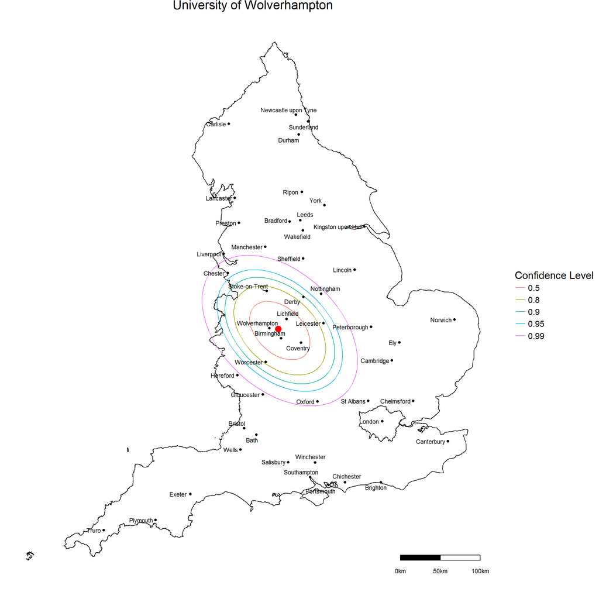

For University of Wolverhampton 76 % of leavers travel 25km or less to their first job as NQT and 5 % travel more than 100km. The percentage of students staying within 25km of University of Wolverhampton is higher than the regional average.

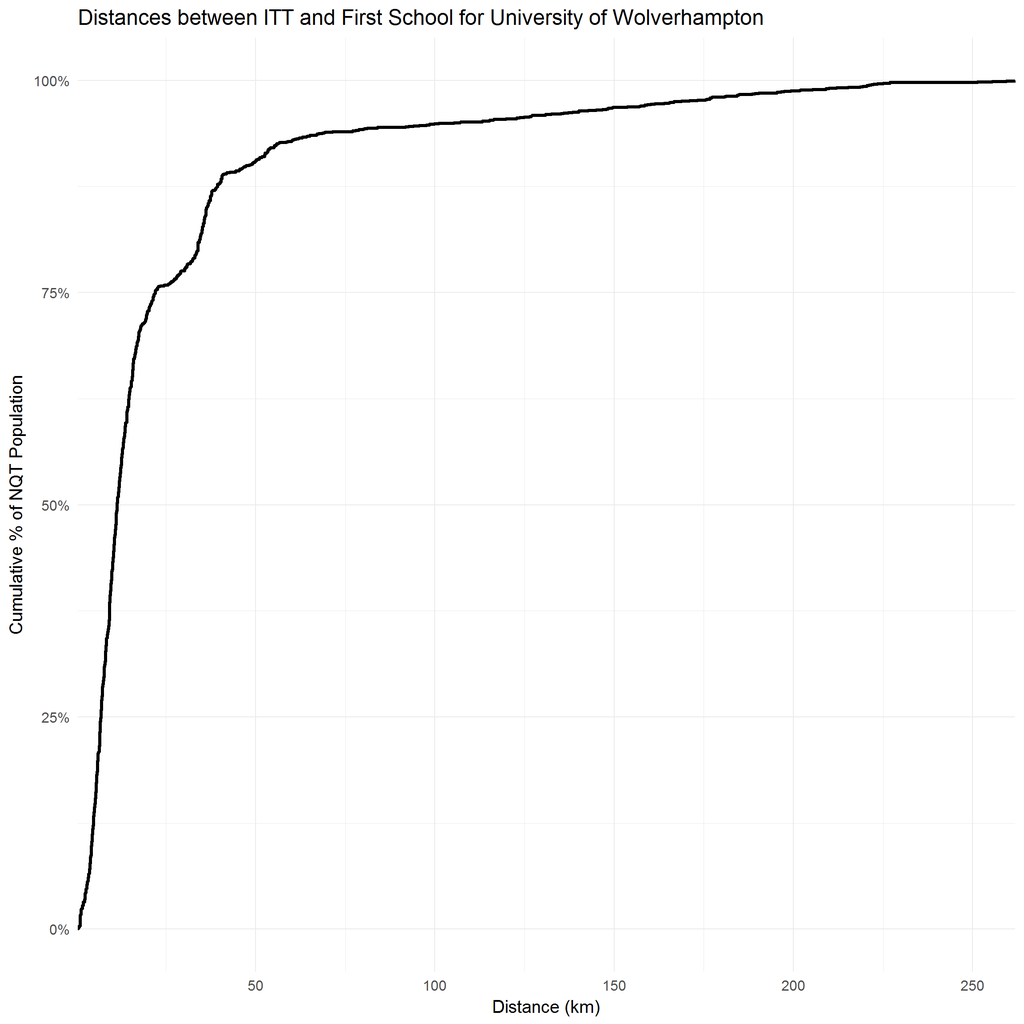

## University of Warwick

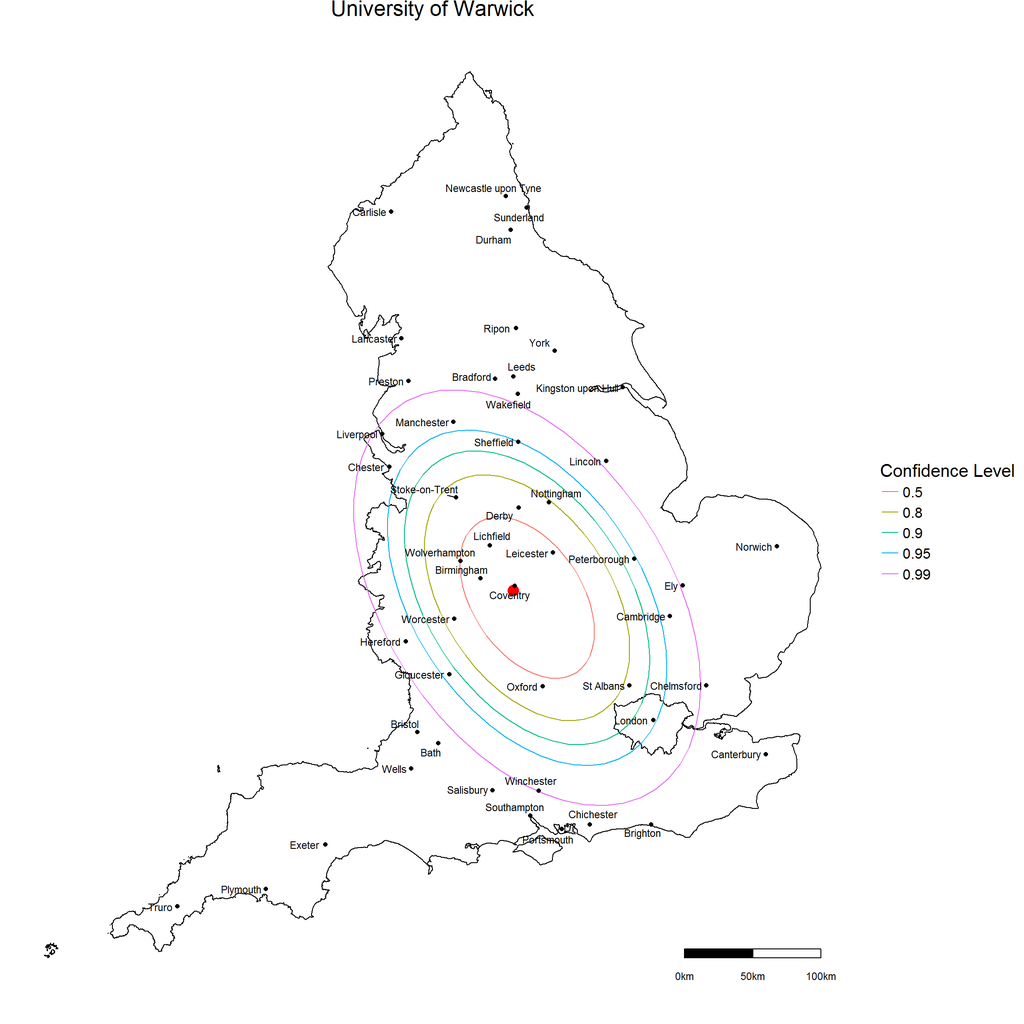

For University of Warwick 60 % of leavers travel 25km or less to their first job as NQT and 16 % travel more than 100km. The percentage of students staying within 25km of University of Warwick is lower than the regional average.

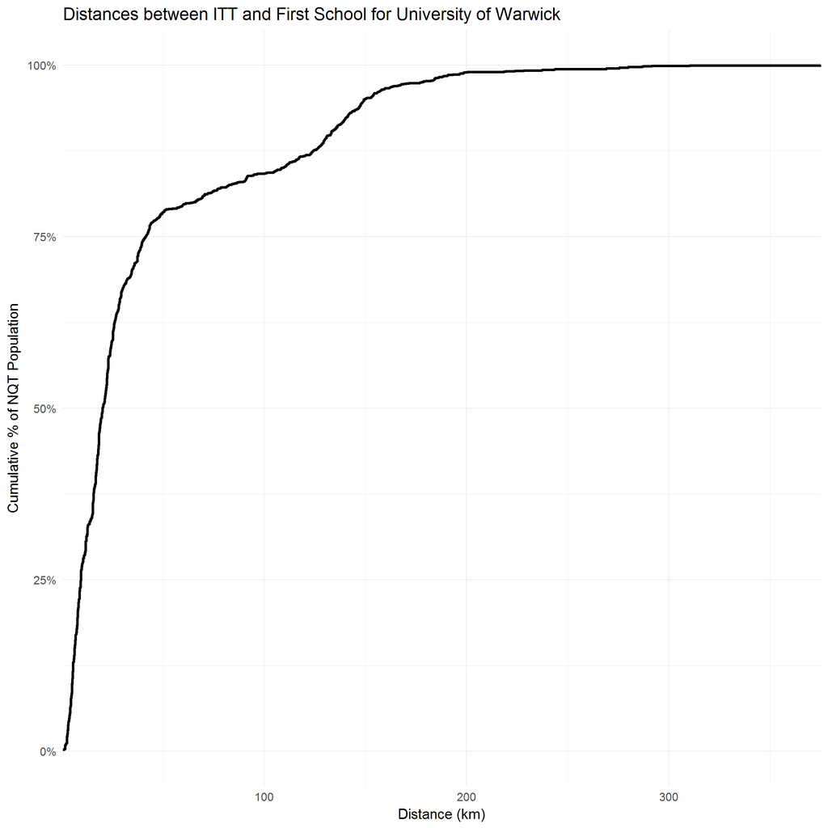

## Birmingham City University

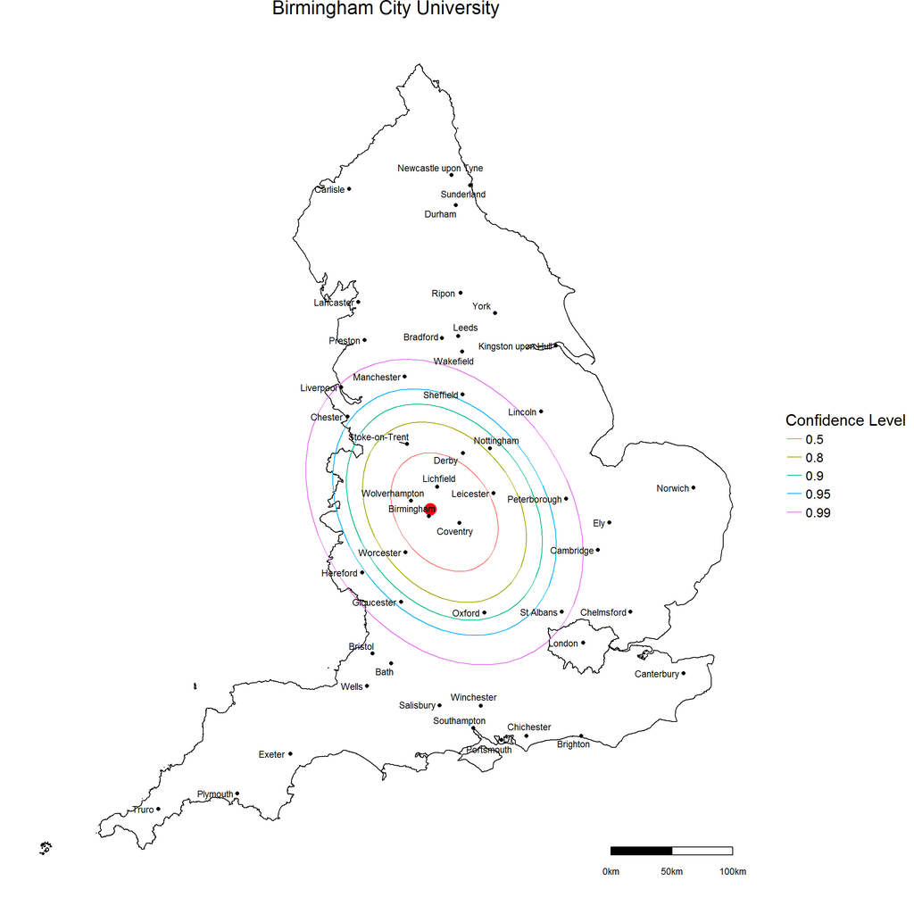

For Birmingham City University 66 % of leavers travel 25km or less to their first job as NQT and 10 % travel more than 100km. The percentage of students staying within 25km of Birmingham City University is higher than the regional average.

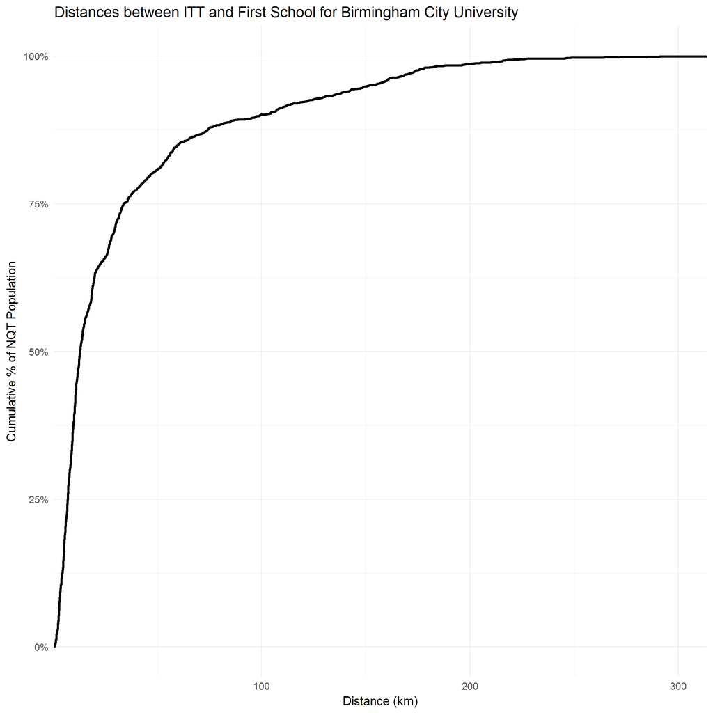

## Newman University

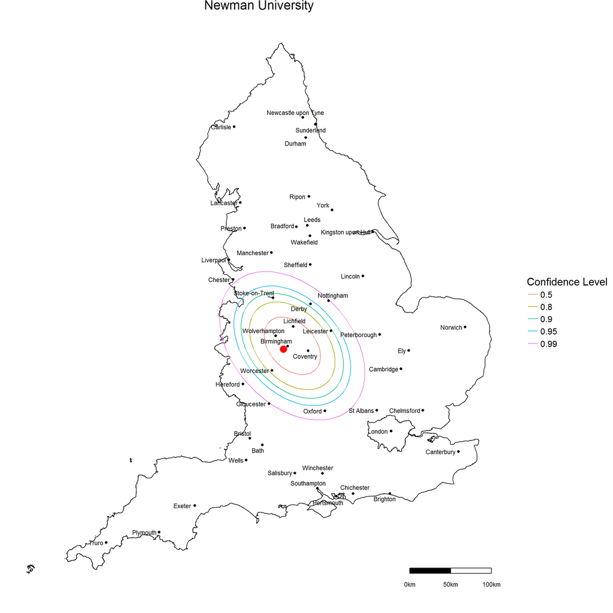

For Newman University 79 % of leavers travel 25km or less to their first job as NQT and 6 % travel more than 100km. The percentage of students staying within 25km of Newman University is higher than the regional average.

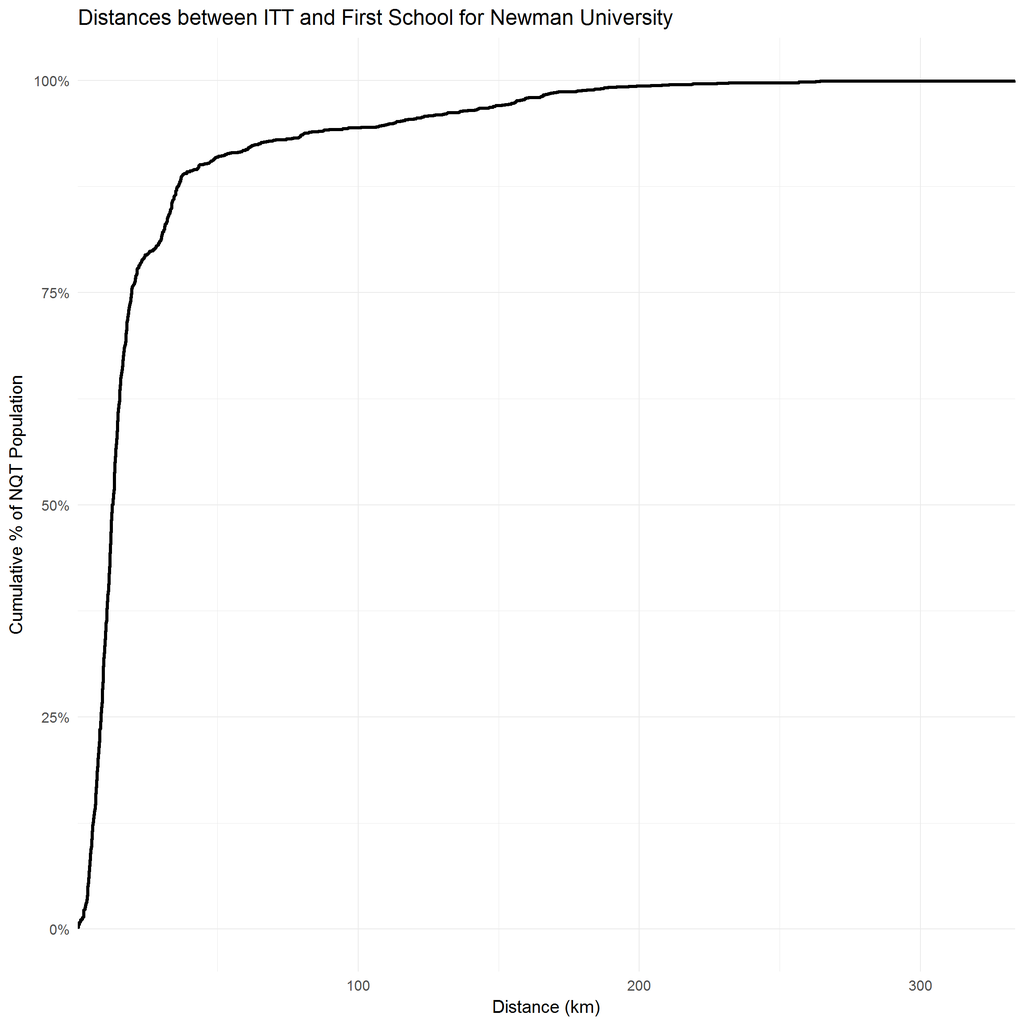

## Staffordshire University

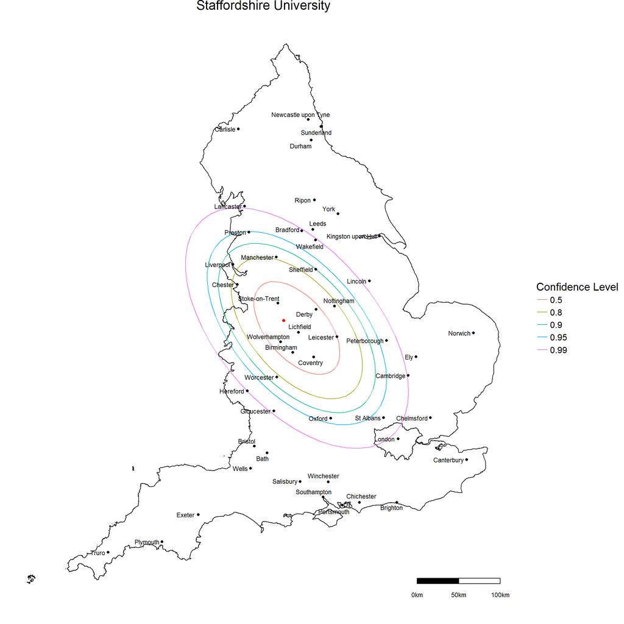

For Staffordshire University 41 % of leavers travel 25km or less to their first job as NQT and 12 % travel more than 100km. The percentage of students staying within 25km of Staffordshire University is lower than the regional average.

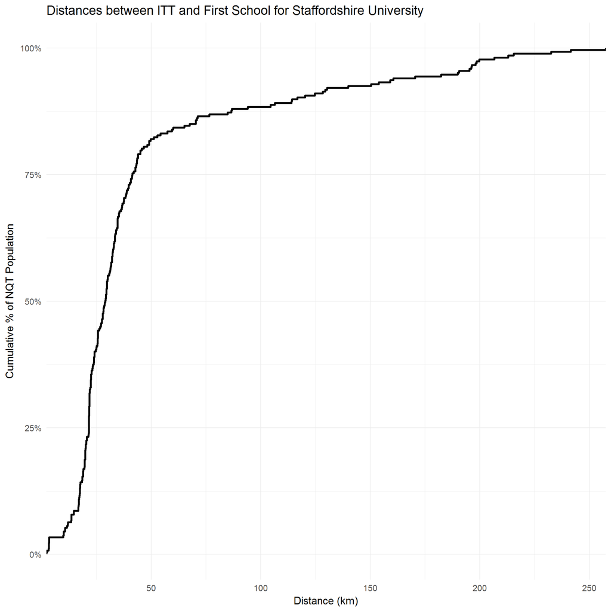

## University of Worcester

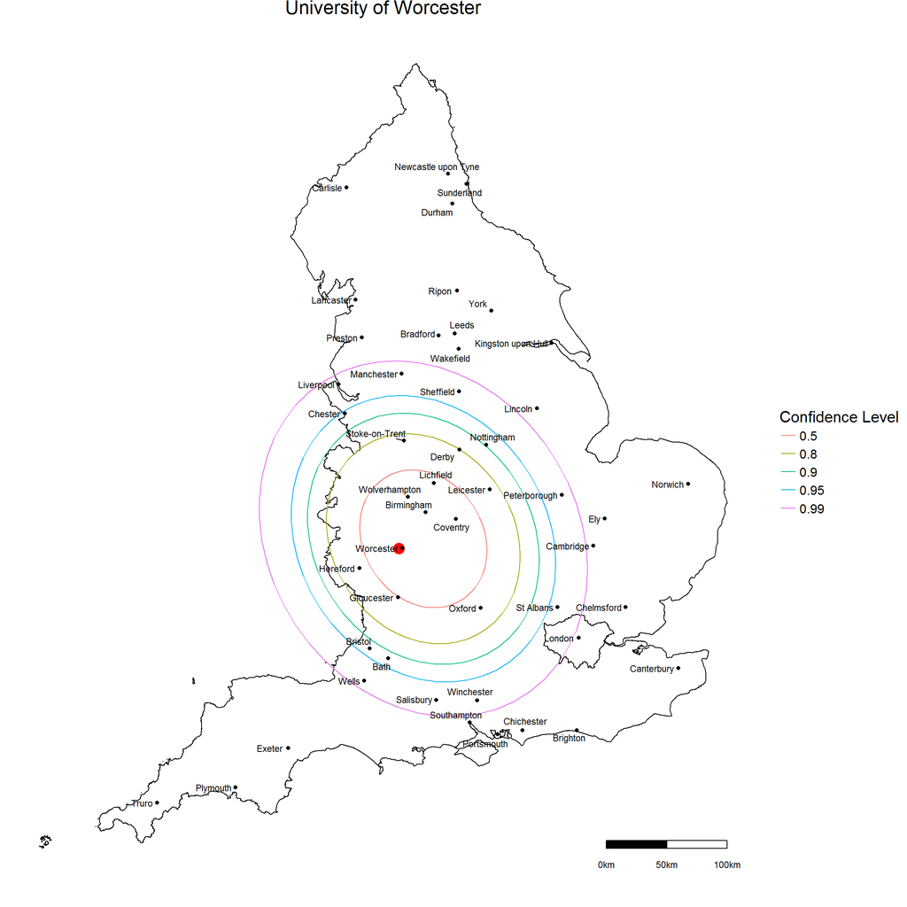

For University of Worcester 28 % of leavers travel 25km or less to their first job as NQT and 13 % travel more than 100km. The percentage of students staying within 25km of University of Worcester is lower than the regional average.

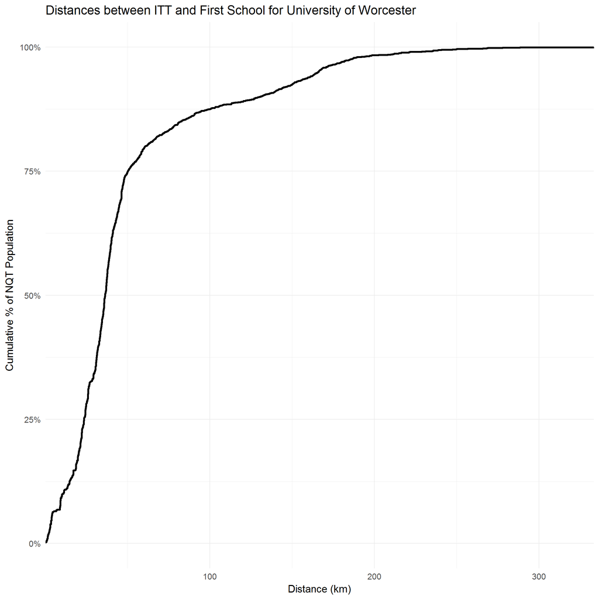

## University College Birmingham

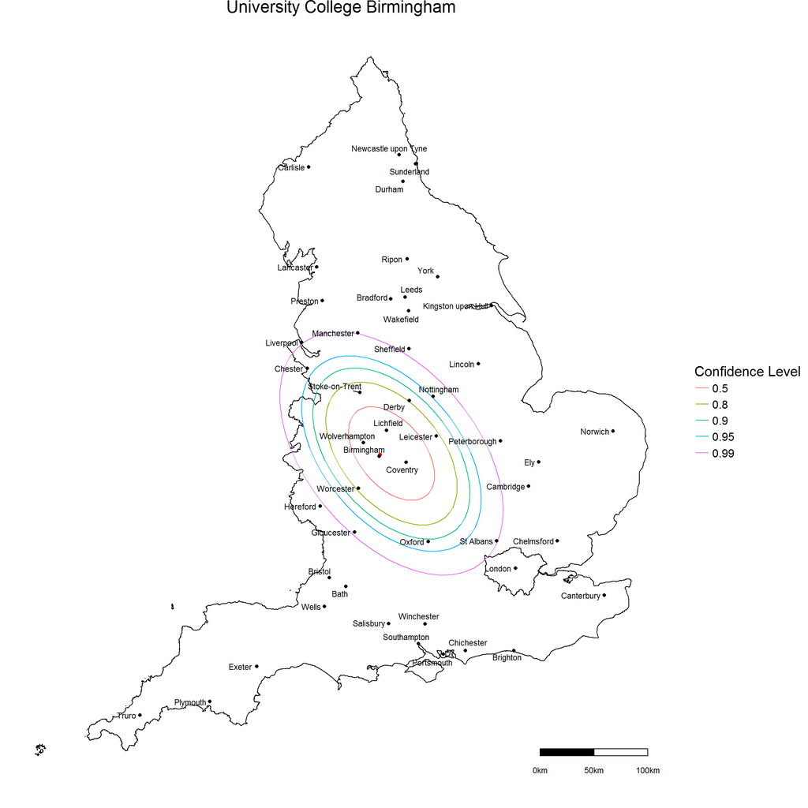

For University College Birmingham 75 % of leavers travel 25km or less to their first job as NQT and 9 % travel more than 100km. The percentage of students staying within 25km of University College Birmingham is higher than the regional average.

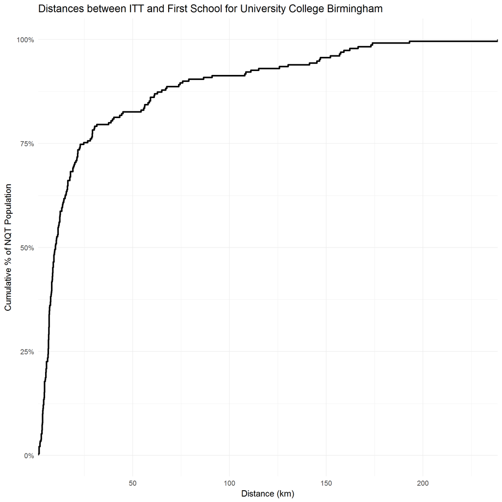

## University of Birmingham

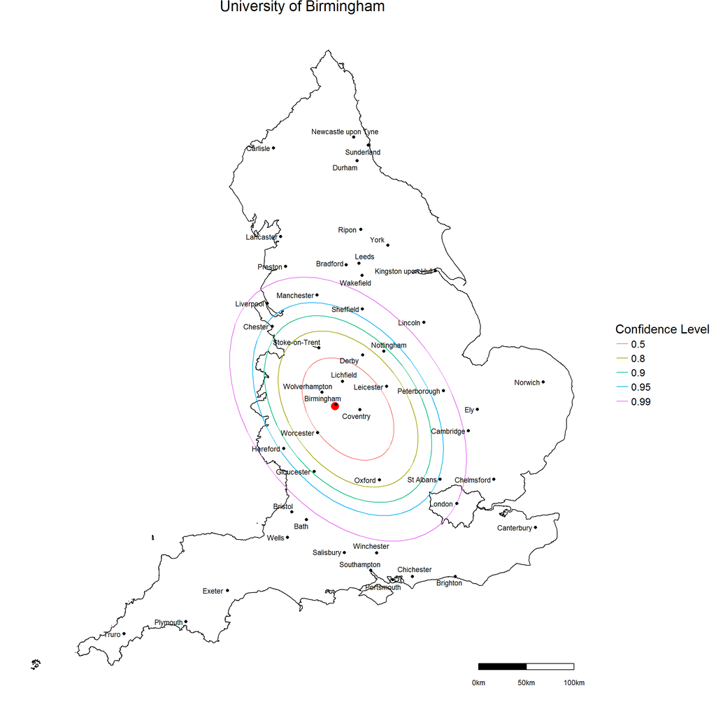

For University of Birmingham 70 % of leavers travel 25km or less to their first job as NQT and 13 % travel more than 100km. The percentage of students staying within 25km of University of Birmingham is higher than the regional average.

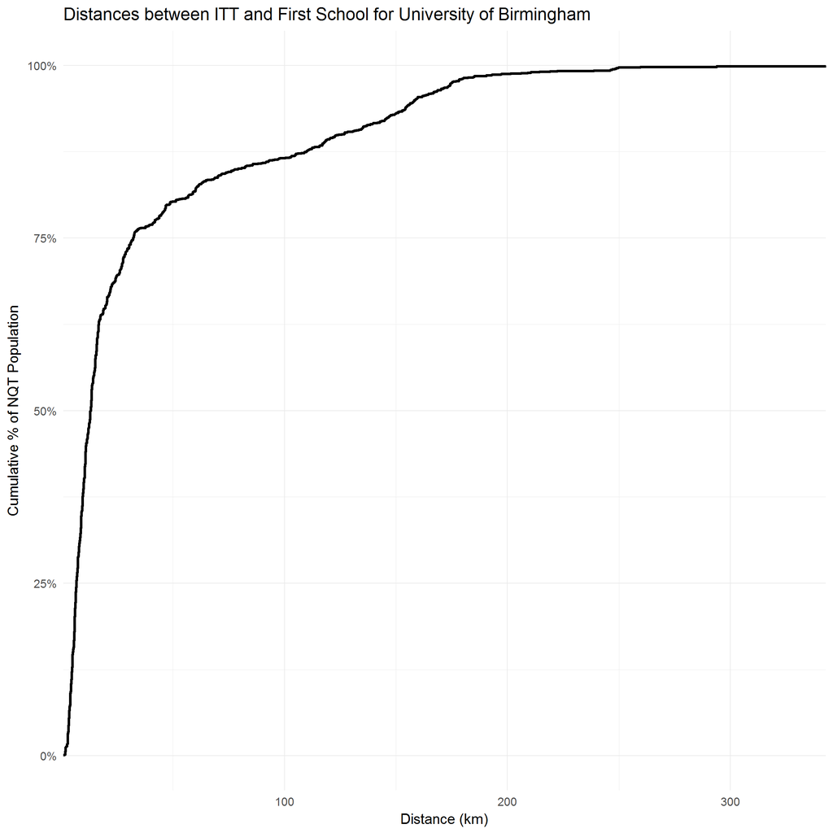

## Titan Partnership Ltd

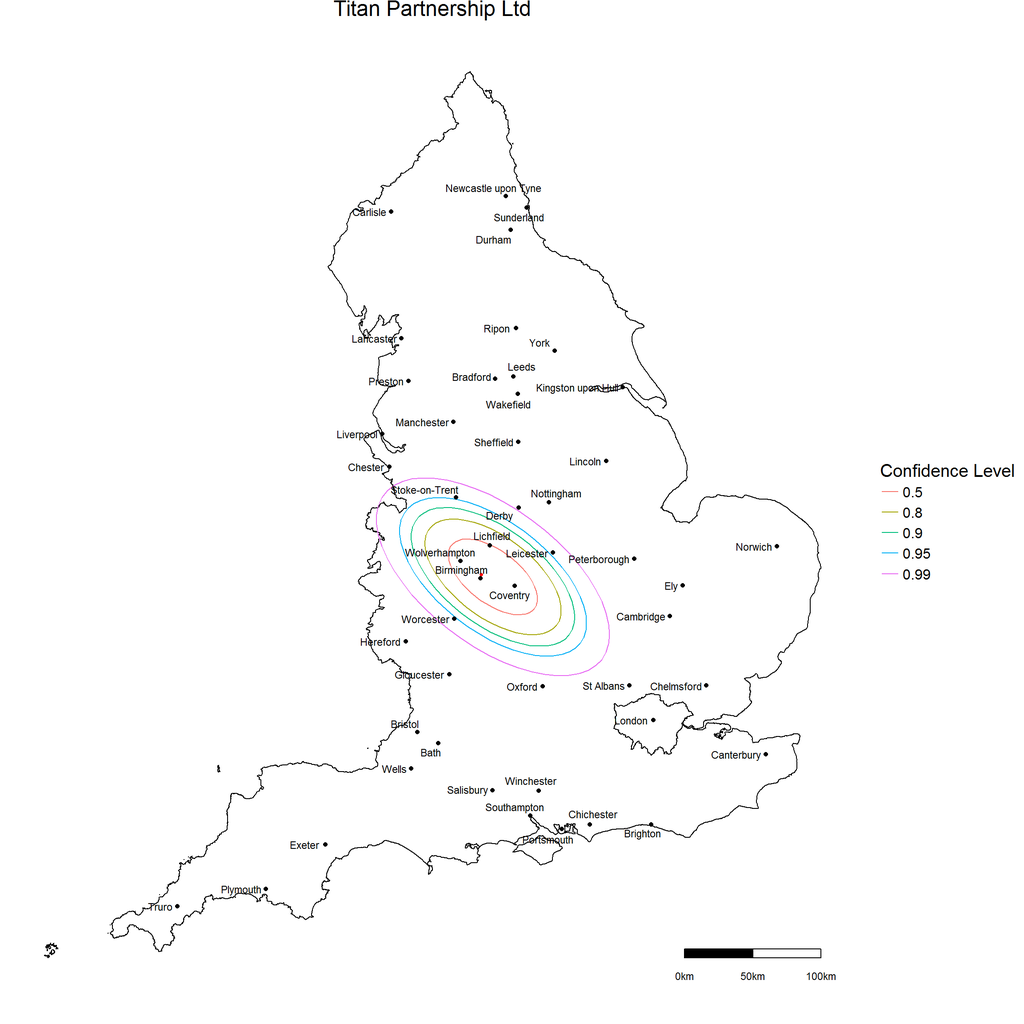

For Titan Partnership Ltd 83 % of leavers travel 25km or less to their first job as NQT and 5 % travel more than 100km. The percentage of students staying within 25km of Titan Partnership Ltd is higher than the regional average.

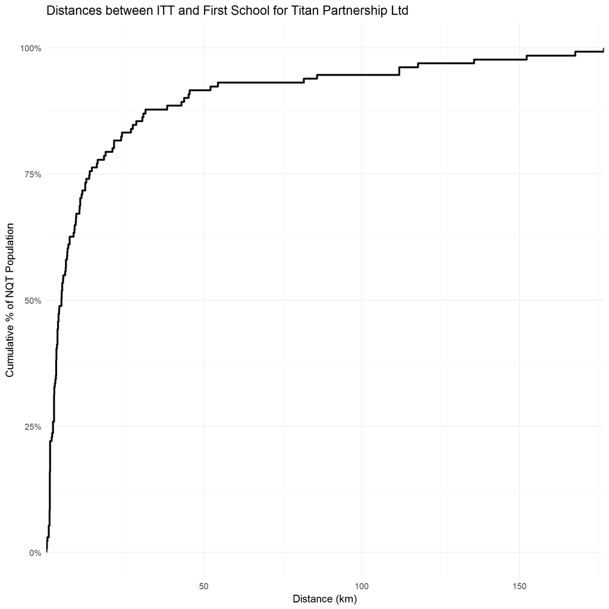

## West Midlands Consortium

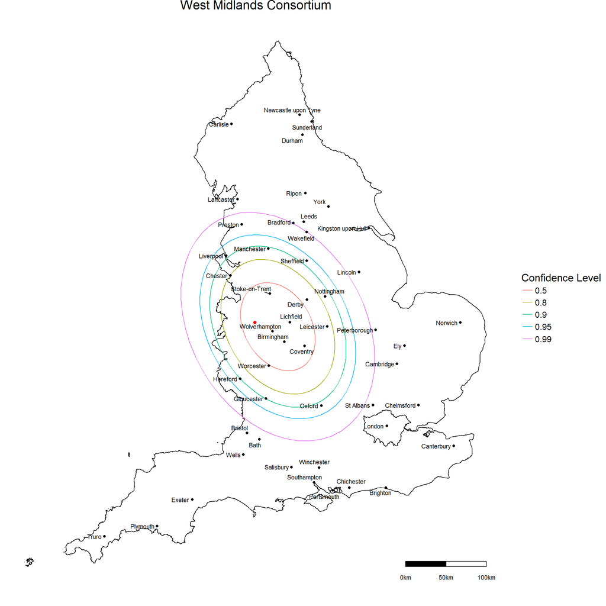

For West Midlands Consortium 31 % of leavers travel 25km or less to their first job as NQT and 11 % travel more than 100km. The percentage of students staying within 25km of West Midlands Consortium is lower than the regional average.

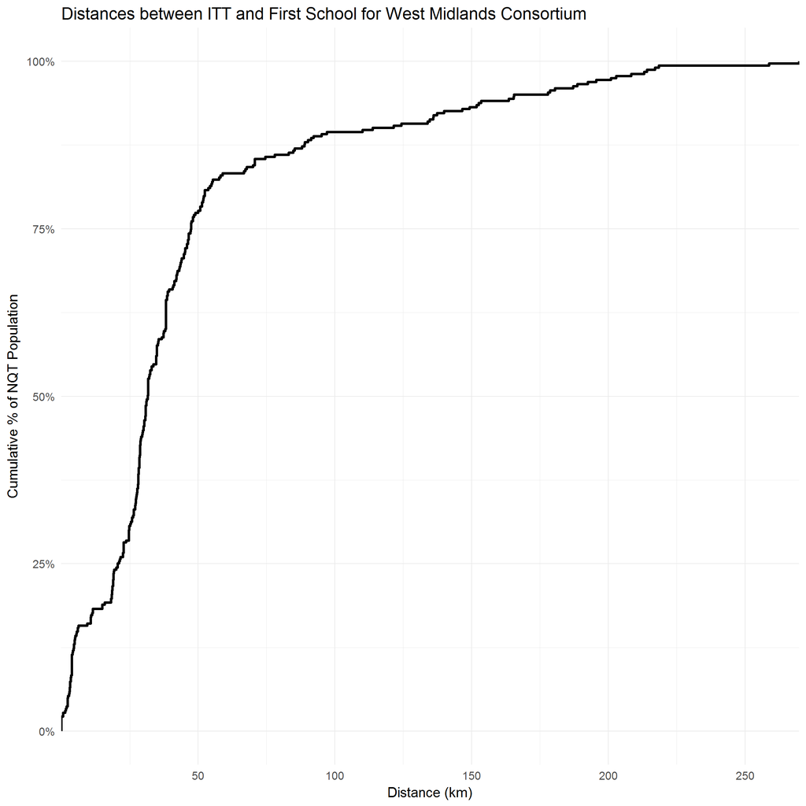

## Keele and North Staffordshire Teacher Education

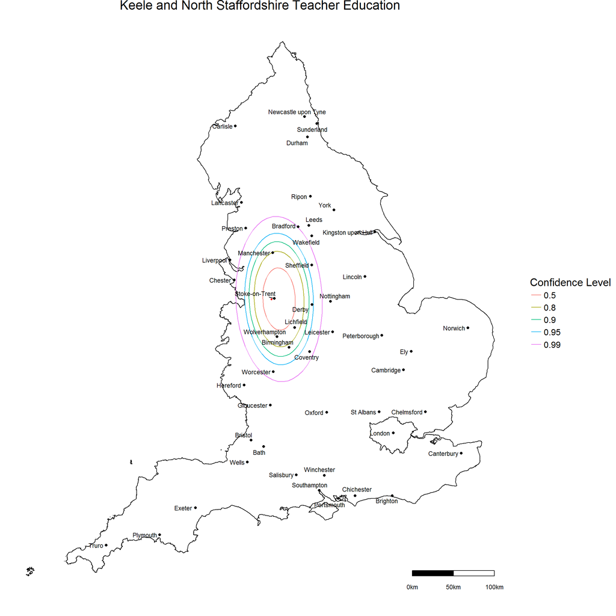

For Keele and North Staffordshire Teacher Education 82 % of leavers travel 25km or less to their first job as NQT and 1 % travel more than 100km. The percentage of students staying within 25km of Keele and North Staffordshire Teacher Education is higher than the regional average.

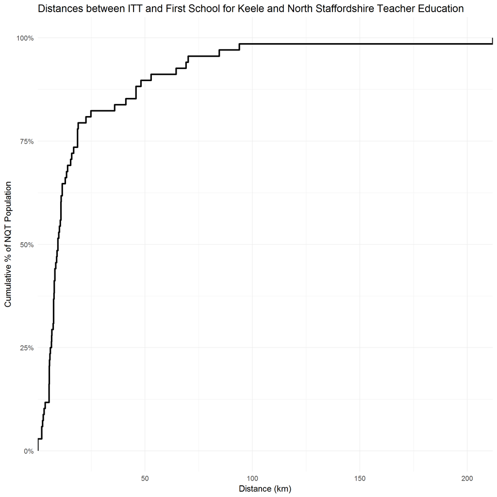

## All providers in West Midlands

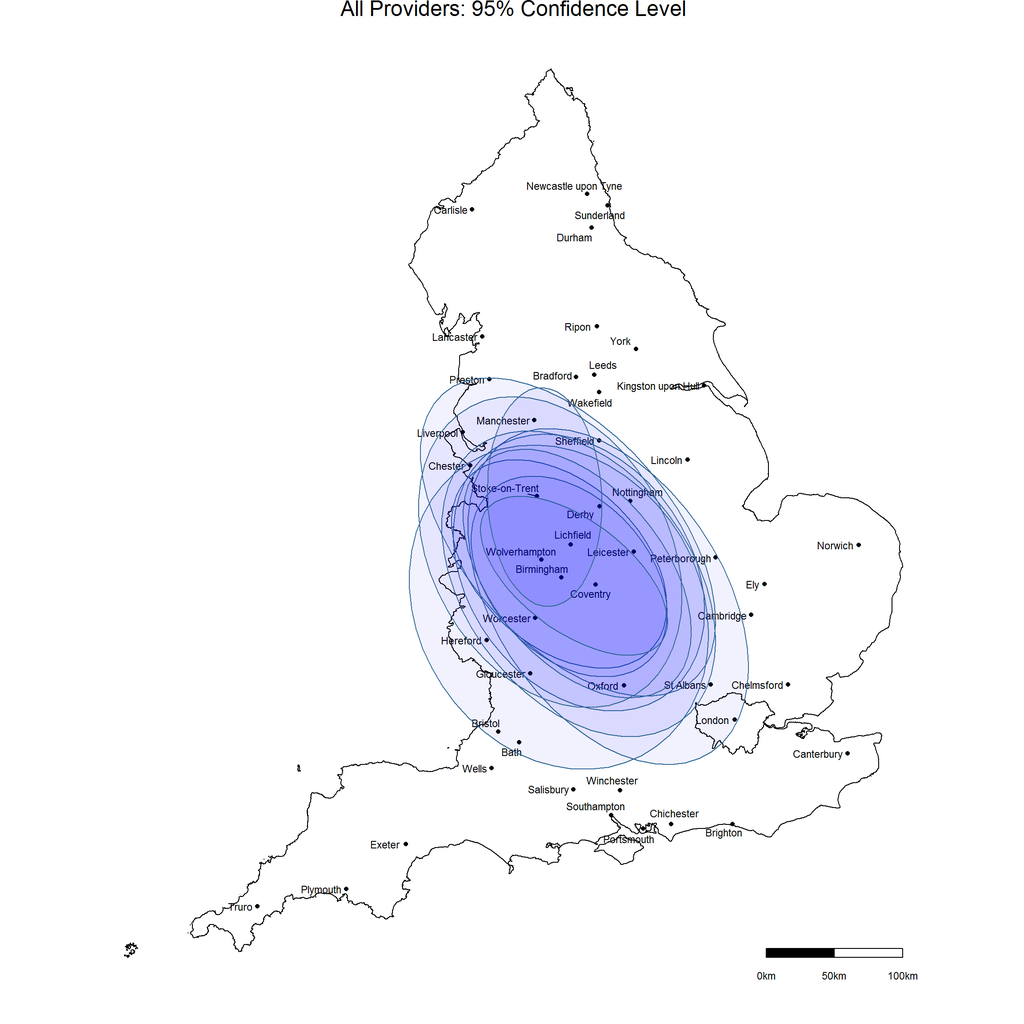

For All providers in West Midlands 61 % of leavers travel 25km or less to their first job as NQT and 10 % travel more than 100km.

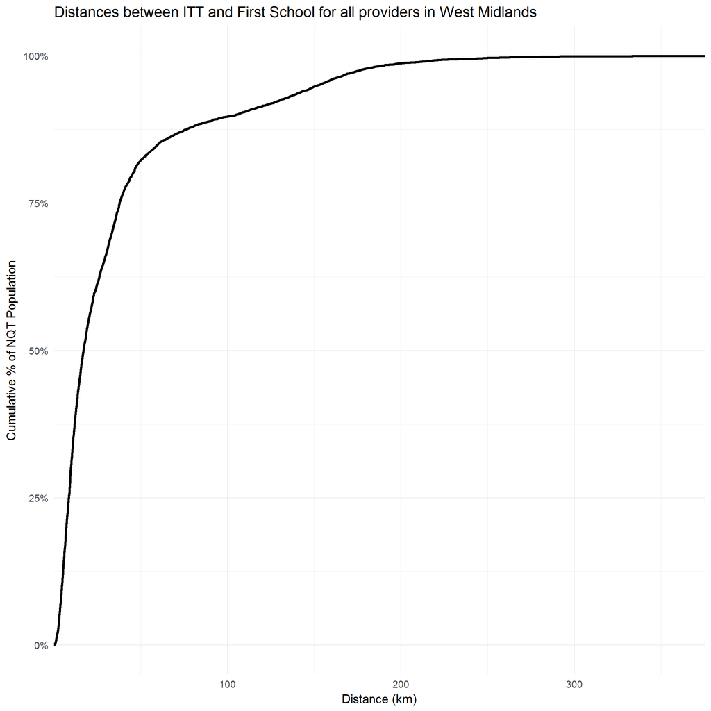

[^1]: Due to an assumption being made about the data being normally distributed the confidence ellipses may not be a complete true reflection of the shape of the area where leavers travel post training. However, the size of the ellipses and their direction can provide meaningful comparison of distances travelled from each provider.
[^2]: The Ellipse’s two axes are in the directions of the eigenvectors of the covariance matrix of the bivariate normal distribution and the middle of the ellipse is the mean of the distribution. The half-length of the axes for each confidence level are the square root of the eigenvalues of the covariance matrix multiplied by the square root of the critical value of a Chi-Squared distribution with 2 degrees of freedom for alpha being 0.05 (1-0.95). We use the R package ggplot2 and the function stat_ellipse to calculate and draw the normal ellipse curves.